# 2.08-Tree-Traversal

1.queue@start = 29 | While Loop | visited_node after pop = 29 | visited = [29] | visited_node.left = 15 & visited_node.right = 44 | queue@end = 15,44 2.Loop | visited_node after pop = 15 | visited = [29,15] | visited_node.left = 9 & visited_node.right = 22 | queue@end = 44,9,22 3.Loop | visited_node after pop = 44 | visited = [29,15,44] | visited_node.left = 40 & visited_node.right = 49 | queue@end = 9,22,40,49 4.Loop | visited_node after pop = 9 | visited = [29,15,44,9] | visited_node.left = 5 & visited_node.right = 10 | queue@end = 22,40,49,5,10 5.Loop | visited_node after pop = 22 | visited = [29,15,44,9,22] | visited_node.left = 19 & visited_node.right = 27 | queue@end = 40,49,5,10,19,27 6.Loop| visited_node after pop = 40 | visited = [29,15,44,9,22,40] | visited_node.left = 35 & visited_node.right = None | queue@end = 49,5,10,19,27,35 7.Loop| visited_node after pop = 49| visited = [29,15,44,9,22,40,49]| visited_node.left = 46 & visited_node.right = 58|queue@end = 5,10,19,27,35,46,58 8.Loop|visited_node after pop = 5|visited =[29,15,44,9,22,40,49,5]| visited_node.left = 2 & visited_node.right = 8|queue@end = 10,19,27,35,46,58,2,8 9.Loop|visited_node after pop=10|visited =[29,15,44,9,22,40,49,5,10]|visited_node.left=None & visited_node.right =12|queue@end= 19,27,35,46,58,2,8,12 10.Loop|visited_node =19|visited=[29,15,44,9,22,40,49,5,10,19]|visited_node.left=None & visited_node.right =21|queue@end= 27,35,46,58,2,8,12,21 11.Loop|visited_node =27|visited=[29,15,44,9,22,40,49,5,10,19,27]|visited_node.left=None & visited_node.right =None|queue@end= 35,46,58,2,8,12,21 12.Loop|visited_node =35|visited=[29,15,44,9,22,40,49,5,10,19,27,35]|visited_node.left=31 & visited_node.right =39|queue@end= 46,58,2,8,12,21,31,39 13.Loop|visited_node =46|visited=[29,15,44,9,22,40,49,5,10,19,27,35,46]|visited_node.left=45 & visited_node.right =None|queue@end= 58,2,8,12,21,31,39,45 14.Loop|visited_node =58|visited=[29,15,44,9,22,40,49,5,10,19,27,35,46,58]|visited_node.left=None & visited_node.right=None|queue@end=2,8,12,21,31,39,45 15.Loop|visited_node =2|visited=[29,15,44,9,22,40,49,5,10,19,27,35,46,58,2]|visited_node.left=None & visited_node.right=None|queue@end=8,12,21,31,39,45 16.Loop|visited_node =8|visited=[29,15,44,9,22,40,49,5,10,19,27,35,46,58,2,8]|visited_node.left=None & visited_node.right=None|queue@end=12,21,31,39,45 17.Loop|visited_node =12|visited=[29,15,44,9,22,40,49,5,10,19,27,35,46,58,2,8,12]|visited_node.left=None & visited_node.right=None|queue@end=21,31,39,45 18.Loop|visited_node =21|visited=[29,15,44,9,22,40,49,5,10,19,27,35,46,58,2,8,12,21]|visited_node.left=None & visited_node.right=None|queue@end=31,39,45 19.Loop|visited_node =31|visited=[29,15,44,9,22,40,49,5,10,19,27,35,46,58,2,8,12,21,31]|visited_node.left=None & visited_node.right=None|queue@end=39,45 20.Loop|visited_node =39|visited=[29,15,44,9,22,40,49,5,10,19,27,35,46,58,2,8,12,21,31,39]|visited_node.left=None & visited_node.right=None|queue@end=45 21.Loop|visited_node =45|visited=[29,15,44,9,22,40,49,5,10,19,27,35,46,58,2,8,12,21,31,39,45]|visited_node.left=None & visited_node.right=None|queue@end=

**Quick analogy on visited_node vs visited**

Think of it like this:

- Assignment () → Replace the text on a whiteboard. Each loop erases the old text and writes new text.
- Append () → Add a new sticky note to a wall. Each loop adds another note, so you keep the whole history.

the `deque` only contains one element: the root node of the tree. It does not magically know about the entire tree. It’s just a container, initially holding the starting point.

**How do we “read” the tree then?** The traversal happens dynamically:

- Start with root in the queue.
- Pop the front of the queue (popleft()).
- Process that node (e.g., record it in visited).
- Enqueue its children (left and right, if they exist).
- Repeat until the queue is empty.

**Analogy**

Think of the deque as a to‑do list:

- At first, your to‑do list has just one task: “visit the root.”
- When you finish that task, you add new tasks: “visit left child” and “visit right child.”
- The deque ensures you always handle tasks in FIFO order, which gives you level‑by‑level traversal.

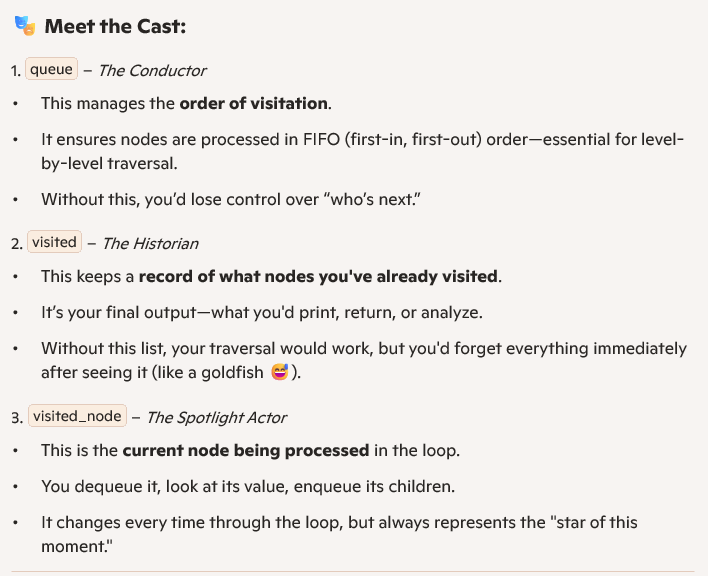

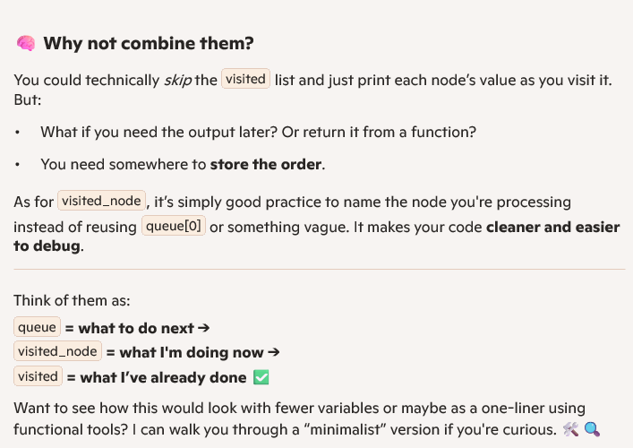

It feels like queue and visited_node might be doing similar things—but they actually play very different roles in how the traversal flows.

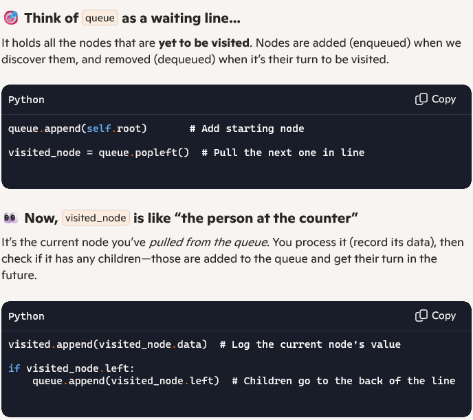

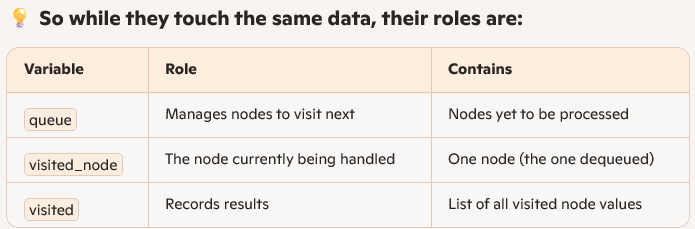

#### Time And Space Complexity

what about the time complexity of the breadth first traversal? What do you think that would be?

What we need to be looking at in order to answer that is the `while loop`. Because this is not a for loop where we could instantly see over how many items we're iterating. Assessing the time performance might seem a bit more difficult, but in reality it's not. One hint we have inside the loop is the number of nodes we're visiting with each iteration.And as we can see, that number is one. So we're visiting one node with each loop.This means that we'll be doing as many loops as there are nodes in the tree.So for a tree of n nodes we would have an O(n) complexity.

Let's now check the space complexity.In our method.We're creating two additional containers where we store some data a queue and the visited list.And visited list is there because that's our definition of visiting a node. So technically we should analyze the performance of this algorithm without it, since in any other circumstancevisiting a node might not use extra memory. So if we ignore the visited list and we focus only on the queue, what would the memory usage be?

To answer that, we need to think about how we use the queue to store the nodes.It's true that we're adding all the nodes to the queue, but they're not all of them in there at the same time. We're freeing some memory when we pop from the queue and we visit the node. Right now we don't have that many nodes stored in memory, but as we keep moving down, the queue will start holding more and more of them.Basically, the queue will occupy the most amount of memory when we reach the widest part of the tree,which is typically at the bottom of the tree.So even though we almost never store the entire tree in the queue, the amount of nodes we have in memory at any time will grow proportionally to the size of the tree.So the space complexity is also O(n)

##### Time : *O* (n)

##### Space : *O* (n)

### Depth First Traversal (DFT) Pre Order Iterative

If Breadth first requires us to visit the tree level by level and move down only after finishing the current level, depth first is the opposite of that. In this type of traversing, we proceed as far down as we can on one branch, and when we reach its end, we go back up to the nearest crossroad and then go all the way down on the next branch, and so on. And we can start this process from left to right like we did here. Or from right to left. Both of them are valid depth-first strategies. As long as we prioritize going down the branch before doing its side to side. Although this method gives us a clear rule of how to move from one node to another, it doesn't specify when we visit the nodes

Do we visit them as we move down the tree? Do we first go all the way down and start visiting when coming back up? These types of questions have prompted a few variations of the same traversing method to be developed, namely the preorder, the in-order, and the post-order traversals. They all have a depth first approach, but they all visit the node at different times during the process.

Putting this type of logic in code would seem a pretty daunting task, but it's actually surprisingly easy if we use another data structure we already learned... **THE STACK**.

Queue uses **`FIFO`** which works fine with **Breadth First Traversal** (Add to Queue-> Popleft -> find children -> Add to queue)

while Stack which uses **`LIFO`** is best fit for **Depth First Traversal Tree**.

When it comes to the Code, the entire method is extremely similar to the breadth first traversal. The only difference is that we're using a stack instead of a queue, and we therefore prioritize visiting the last node that was added to our stack. Everything else is pretty much the same

We start at the root and before moving to any of its children, we mark it as visited. And then we need to choose one path to go to, either to the left or to the right. For the `iterative version, we'll go to the right side first`, and `for the recursive version we'll go to the left one`.

So after the root(`29`), we go to its right child(`44`) and we mark it as visited. After that we don't move to `15` but continue downwards to `49`.We visit it and then to `58`. Since we now reached the end of the branch, `we go up one step back` to `49` and check if it has any left child. If it does, we visit it and now we check for the right child of `46`. But since it doesn't have one, we go to `45` and we visit that instead. Now that we visited all the nodes that stem out of `49`, we go again one step up to the next branching, which is at `44`.We then visit `40`, and since it doesn't have a right child, we check its left one. We visit `35` and then check for the right child. This time we have one `39`, so we mark it as visited. And since we reached the end of this branch, we go back to `35` and check for the left child`31`. We visit that as well and we're done with the right side of the tree. Going back one more time to the next branching would mean going back to the root`29`. Visiting the left child `15`and then repeating the same process for all the remaining nodes.

```python
class Node:
    def __init__(self,data):
        '''This creates a node that holds :  a)data:the value   b)left: left child reference   c)right: right child reference'''
        self.data=data
        self.left=None
        self.right=None

class BinarySearchTree:
    def __init__(self):
        self.root=None

#We have maintained the same code as DFT with few changes 1)we have used self.root directly inside stack,instead of asigning to a variable (queue=deque()
# 2. replace queue with stack , 3. replaced popleft with just pop. With these changes we have now converted DFT to BFT code
    def dft_pre_order_iterative(self):
        ''' Defines the method within the BinarySearchTree class. We're avoiding recursion and using a stack for iteration.'''
        if not self.root:
            raise Exception("Tree is Empty")
        stack = [self.root] # instead of queue=deque() & then queue.append(self.root) we can directly add root to stack. This is similar to below code
# stack = []
# stack.append(self.root)
        visited = [] # Initializes an empty list to collect the values of nodes as they are visited. Not the nodes themselves, just their data.
        while stack: # - Loops as long as there are nodes in the stack.
# pop.left removes the oldest node added,ensuring you visit nodes level by level,left to right,while regular pop is used to remove the most recently
# added node. This lets you go deep into one branch before backtracking.
# Also when you use pop() on a list without specifying an index, it removes and returns the last element—which is the one on the right end of the list.
            visited_node = stack.pop() # change pop.left to regular pop.
            visited.append(visited_node.data) # The attribute you defined to hold the node's value is called data, not values
            if visited_node.left:# since visited_node is reset everytime,we capture left & right child(whichever present) of a new parent node everytime
                stack.append(visited_node.left)
            if visited_node.right:
                stack.append(visited_node.right)
        return visited
```

In BFT we used `Queue` and `popped left` (pick first element from left) and then `added their left and right child`.

In DFT PreOrder(Root->Right->Left)Iterative(stack) we use `Stack(LIFO)` and `pop the latest node(from right)` and then `add their right and left child`

Lets look at how differently DFT traverses and how the elements are extracted/popped and stored under "visited" container

```python
1.stack@start = 29 | While Loop | visited_node after pop = 29 | visited = [29]  | visited_node.left = 15 & visited_node.right = 44 | stack@end = 15,44
2.Loop | visited_node after pop = 44 | visited = [29,44] | visited_node.left = 40 & visited_node.right = 49 | stack@end = 15,40,49
3.Loop | visited_node after pop = 49 | visited = [29,44,49] | visited_node.left = 46 & visited_node.right = 58 | stack@end = 15,40,46,58
4.Loop | visited_node after pop = 58 | visited = [29,44,49,58] | visited_node.left = None & visited_node.right = None | stack@end = 15,40,46
5.Loop | visited_node after pop = 46 | visited = [29,44,49,58,46] | visited_node.left = 45 & visited_node.right = None | stack@end = 15,40,45
6.Loop| visited_node after pop = 45 | visited = [29,44,49,58,46,45] | visited_node.left = None & visited_node.right = None | stack@end = 15,40
7.Loop| visited_node after pop = 40| visited = [29,44,49,58,46,45,40]| visited_node.left = 35 & visited_node.right = None|stack@end = 15,35
8.Loop| visited_node after pop = 35| visited = [29,44,49,58,46,45,40,35]| visited_node.left = 31 & visited_node.right = 39|stack@end = 15,31,39
9.Loop|visited_node after pop = 39|visited =[29,44,49,58,46,45,40,35,39]| visited_node.left = None & visited_node.right = None|stack@end = 15,31
10.Loop|visited_node after pop=31|visited =[29,44,49,58,46,45,40,35,39,31]|visited_node.left=None & visited_node.right =None|stack@end= 15
11.Loop|visited_node =15|visited=[29,44,49,58,46,45,40,35,39,31,15]|visited_node.left=9 & visited_node.right =22|stack@end= 9,22
12.Loop|visited_node =22|visited=[29,44,49,58,46,45,40,35,39,31,15,22]|visited_node.left=19 & visited_node.right =27|stack@end= 9,19,27
13.Loop|visited_node =27|visited=[29,44,49,58,46,45,40,35,39,31,15,22,27]|visited_node.left=None & visited_node.right =None|stack@end=9,19
14.Loop|visited_node =19|visited=[29,44,49,58,46,45,40,35,39,31,15,22,27,19]|visited_node.left=None & visited_node.right =21|stack@end=9,21
15.Loop|visited_node =21|visited=[29,44,49,58,46,45,40,35,39,31,15,22,27,19,21]|visited_node.left=None & visited_node.right=None|stack@end= 9
16.Loop|visited_node =9|visited=[29,44,49,58,46,45,40,35,39,31,15,22,27,19,21,9]|visited_node.left=5 & visited_node.right=10|stack@end= 5,10
17.Loop|visited_node =10|visited=[29,44,49,58,46,45,40,35,39,31,15,22,27,19,21,9,10]|visited_node.left=None & visited_node.right=12|stack@end=5,12
18.Loop|visited_node =12|visited=[29,44,49,58,46,45,40,35,39,31,15,22,27,19,21,9,10,12]|visited_node.left=None & visited_node.right=None|stack@end= 5
19.Loop|visited_node =5|visited=[29,44,49,58,46,45,40,35,39,31,15,22,27,19,21,9,10,12,5]|visited_node.left=2 & visited_node.right=8|stack@end= 2,8
20.Loop|visited_node =8|visited=[29,44,49,58,46,45,40,35,39,31,15,22,27,19,21,9,10,12,5,8]|visited_node.left=None & visited_node.right=None|stack@end= 2
21.Loop|visited_node =2|visited=[29,44,49,58,46,45,40,35,39,31,15,22,27,19,21,9,10,12,5,8,2]|visited_node.left=None & visited_node.right=None|stack@end=
```

#### Time And Space Complexity

Talking about the complexity of this function.It hasn't changed compared to the other method we learned.It's still O(n) for both time and space.

However if we talk about the memory utilization here, With the breadth first traversal, the maximum amount of memory we used was when the tree was the widest,which was usually at the bottom.With this new method, the number of nodes we keep in our stack is proportional to the depth of thebranches.So this is again not always an O(n) space consumption.

But if we consider the edge cases where the tree is very skinny or skewed to one side, we have to generalize that complexity to O(n)

##### Time : *O* (n)

##### Space : *O* (n)

### Depth First Traversal (DFT) Pre Order Recursive

When it comes to any of the depth first traversal algorithms, you'll almost always see them implemented using recursion, and there's a good reason for that. They require way less code, and to some people they're more intuitive than their iterative counterparts.

We have discussed both versions in this section, just to give you an idea of how two implementations of the same algorithm might differ. Just to be clear, this is still the preorder depth first traversal. We're still traversing the tree the same way we did in the previous section, but this time we'll use recursion instead of iteration.

```python
def dft_pre_order_recursive(self):
    if not self.root:
        raise Exception("Tree is empty")
    visited = []

    def _traverse(node):
        if node:
            visited.append(node.data)
            _traverse(node.left)
            _traverse(node.right)
        return

    _traverse(self.root)
    return visited
```

In this Recursion function , when the node has children , it dives deeper, but the Parent loop doesn’t close till the children loop has finished. Each new _traverse(...) call goes on top of the stack as highlighted above(just like stacking plates). When a call finishes, it's removed from the top (unstacked).

Its starts with Root(`29`), `29` is appended to "Visited", then `29.left (15)` function is activated ..now the baton is passed to `15` , but `29` loop is still open, since `29.right` function is waiting for `29.left` function to finish. Node `15` follows the same pattern and passes the baton to `9` `(15.left)` ..while `15.right` is waiting and so is `29.right`…this goes on till we reach the last node/leaf and when we get `node.left =None` `(2.left=None)`as response, the function returns immediately and pops off. Now we are still within `_traverse(2)` function, `_traverse(2.left)` has returned None, we now activate `_traverse(2.right)`, which also returns None. This completes `_traverse(2)` loop and the control returns to previous/parent branch `_traverse(5)`. Now `_traverse(5)` will execute its second function `_traverse(5.right)` which results in `_traverse(8)`, when this loop also closes, the baton is passed back to `_traverse(5)` and when all functions with `_traverse(5)` are completed, the baton is passed back to parent node `_traverse(9)`. This continues till it reaches `root(29)` and now `_traverse(29)` will execute its pending function `_traverse(20.right)`

[figure not shown]

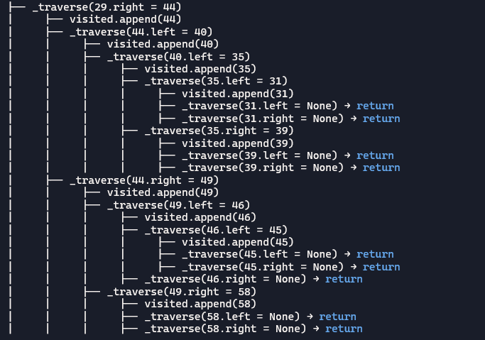

Root → Left → Right

That’s the defining trait of pre-order traversal, regardless of how you implement it.

🧠 So why the name “pre-order”? The term comes from the position of the root node in the traversal sequence:

- In pre-order, the root is visited before its children.
- In in-order, the root is visited between its children (Left → Root → Right).
- In post-order, the root is visited after its children (Left → Right → Root).

So the “pre” in pre-order means the root comes first—not that it’s recursive or iterative.

As long as the traversal visits nodes in Root → Left → Right order, it’s pre-order—no matter how you get there.

Another side note, you might have noticed that we now went to the left side of the tree as opposed to the previous section where we started with the right one. And that's just due to the order of which we called the traverse functions (node.left & then node.right). We would achieve the same order as the iterative version if we were to traverse the right child first and then the left one. This is just a detail that matters only if you specifically want to prioritize one side over the other. It doesn't change the fact that we're still traversing preorder depth first

#### Time And Space Complexity

Regarding complexities and like all the other versions, they will be O(n) for both time and space. Please note that we're still using memory, even if we don't have a dedicated stack. We're basically using the systems call stack to achieve the same result we did in the iterative version. And if you pay attention, you'll see that the call stack will only grow with as many frames as the number of nodes in the deepest branch of the tree, because we're constantly popping off functions as they finish executing.

##### Time : *O* (n)

##### Space : *O* (n)

### Depth First Traversal (DFT) In Order Iterative

The 2nd Depth First method we will look at is called in-order. We'll still prioritize moving down the tree before going side to side. But with this one, the order in which we visit the nodes is different. We start at the root just like before, but this time we don't visit the nodes until we reach the end of the branch, and only after that we start visiting. Assuming we go again on the left side first, that would mean going from `29` to `15`, `15` to`9`, then `5`, then `2`, and only after we notice that `2` does not have any children, we visit it. And the order in which we visit nodes in the in order variation is like this.

The left side of a node is visited first, then the root itself, and after that the right side. And after we finish with that subtree, we go up one node and then repeat.

We already visited `2`.So the next one will be `5` and then `8`.And with this mini tree fully visited, we then move up.If we now look at this sub tree that starts at `9`, we can see that we already visited its left side.So we now need to visit `9` itself and start moving down to the right side.We go one step down and try to go to `10s` left, child.But since that doesn't exist, we visit `10` and then go to its right child.Here we have the same thing again.We try to visit the left child, but it doesn't have one.So we visit `12`.And then since it doesn't have a right child, it means that we visited the entire left side of thesubtree that starts at `15`

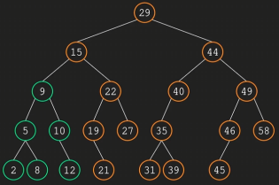

So we visit `15` and then go to the right.When we reach `22`, we try to go to its left where we find `19` and then try to go to `19` left child, but that doesn't exist.We visit `19` and then go to `21`.With the left side of `22` fully visited.We then visit `22` and move to its right side.So that's the theory behind this type of traversing.

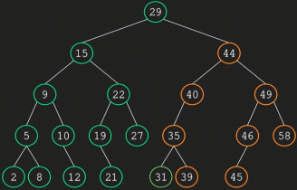

Let's now think how we could implement it using iteration.We would again need to use a stack to store nodes, and we start at the root(`29`) and add it to the stack.After that we check its left child(`15`), and if it exists, we add it to the stack as well.But then we don't add the right child (`44`) like we did previously, but rather moved to `15s` left child(`9`) and add that one instead.And we do the same thing to all the nodes (`5`,`2`) until we reach the bottom.We only add the left children of all the nodes we encounter.

**stack : 29 15 9 5 2**

When we reach the end of the line, we pop the last added node off the stack (`2`) and we visit it.We would then check if this node has any right children.If it doesn't.Like in this case, we pop again (`5`) from the stack and we visit that node.After that we try to traverse towards its right (`5.right`)side.In this case there is indeed a node there (`8`), so we add it to the stack.

**stack : 29 15 9 8**

Since this one doesn't have neither left nor a right child, we pop it(`8`) off the stack and visit it.

**stack : 29 15 9**

In the next iteration, we remove `9` from the stack, visit it, and then traverse its right side.We go to `10`.We add it to the stack and then try to go to its left.

**stack : 29 15 10**

Since it doesn't exist, we pop `10` from the stack, visit it, and go to `12`.

**stack : 29 15 12**

And the process repeats until the stack is empty.We try to add to the stack the left child.If it doesn't exist, we pop from the stack, visit, and then go to the right side.

```python
def dft_in_order_iterative(self): # (Left -> Root -> Right)
    if not self.root:
        raise Exception("Tree is empty")
    current_node = self.root
    visited = []
    stack = []
    while stack or current_node: # while loop will never start if stack is empty, hence also add current_node
        ''' This section lets you reach to the leaf. Will be true till it reaches the Left leaf of the tree '''
        if current_node:
            stack.append(current_node)
            current_node = current_node.left # to reach the left most end or leaf of the structure
        else: # if we reach the end of the branch
            ''' This section will help you traverse from left lowest nodes to Root and then cover Right side nodes '''
            visited_node = stack.pop()
            visited.append(visited_node)# Now we start from the left most leaf of the tree & start traversing and capturing the nodes(left-Root-Right)
            if not visited_node.right: # if there is no right child of the leaf then use continue to go back to While loop
                continue #
            current_node = visited_node.right # if there is right node, then current should  be updated
    return visited
```

**Documented in‑order DFS iterative Traversal**